# Lab 5B - Machine Learning in Practice

### 1. Load the Data

1. Load all required libraries.

```python
import os
import pandas as pd
import seaborn as sns
import numpy as np
import matplotlib.pyplot as plt
from sklearn.preprocessing import StandardScaler
from sklearn.model_selection import train_test_split
from sklearn.model_selection import GridSearchCV
from sklearn.neighbors import KNeighborsClassifier
from sklearn.tree import DecisionTreeClassifier
from sklearn.neural_network import MLPClassifier
from sklearn.metrics import accuracy_score
```

2. Set the working directory to "C:\Workshop\Data".

```python
os.chdir("C:\Workshop\Data")
```

3. Read the Risk.csv file into a data frame called *policies*.

```python
policies = pd.read_csv("Risk.csv")
```

### 2. Explore the Data

1. Inspect the policies data using the `head` function.

```python
policies.head()
```

|  | Gender | State | State_Rate | Height | Weight | BMI | Age | Risk |
| --- | --- | --- | --- | --- | --- | --- | --- | --- |
| 0 | Male | MA | 0.100434 | 184 | 67.8 | 20.025992 | 77 | High |
| 1 | Male | VA | 0.141723 | 163 | 89.4 | 33.648237 | 82 | High |
| 2 | Male | NY | 0.090803 | 170 | 81.2 | 28.096886 | 31 | Low |
| 3 | Male | TN | 0.119973 | 175 | 99.7 | 32.555102 | 39 | Low |
| 4 | Male | FL | 0.110345 | 184 | 72.1 | 21.296078 | 68 | High |

2. Summarize the columns in the data frame using the `info` function.

```python
policies.info()
```

```
<class 'pandas.core.frame.DataFrame'>
RangeIndex: 1942 entries, 0 to 1941
Data columns (total 8 columns):
Gender        1942 non-null object
State         1942 non-null object
State_Rate    1942 non-null float64
Height        1942 non-null int64
Weight        1942 non-null float64
BMI           1942 non-null float64
Age           1942 non-null int64
Risk          1942 non-null object
dtypes: float64(3), int64(2), object(3)
memory usage: 121.5+ KB
```

3. Sumarize the data in the data frame using the `describe` function.

```python
policies.describe(
    include = "all")
```

|  | Gender | State | State_Rate | Height | Weight | BMI | Age | Risk |
| --- | --- | --- | --- | --- | --- | --- | --- | --- |
| count | 1942 | 1942 | 1942.000000 | 1942.000000 | 1942.000000 | 1942.000000 | 1942.000000 | 1942 |
| unique | 2 | 51 | NaN | NaN | NaN | NaN | NaN | 2 |
| top | Male | CA | NaN | NaN | NaN | NaN | NaN | Low |
| freq | 986 | 191 | NaN | NaN | NaN | NaN | NaN | 1366 |
| mean | NaN | NaN | 0.138064 | 169.718847 | 81.155767 | 28.292804 | 50.841401 | NaN |
| std | NaN | NaN | 0.044180 | 9.571082 | 16.009041 | 5.808799 | 19.327130 | NaN |
| min | NaN | NaN | 0.001000 | 150.000000 | 44.100000 | 16.022174 | 18.000000 | NaN |
| 25% | NaN | NaN | 0.110345 | 162.000000 | 68.600000 | 23.739705 | 34.000000 | NaN |
| 50% | NaN | NaN | 0.127584 | 170.000000 | 81.300000 | 28.055706 | 51.000000 | NaN |
| 75% | NaN | NaN | 0.144251 | 176.000000 | 93.800000 | 32.456822 | 68.000000 | NaN |
| max | NaN | NaN | 0.318100 | 190.000000 | 116.500000 | 46.796193 | 84.000000 | NaN |

4. Create a correlation matrix using the `corr` function.

```python
correlations = policies.corr()
```

5. Create a correlogram using the seaborn `heatmap` function.

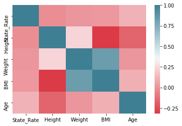

```python
sns.heatmap(
    data = correlations,
    cmap = sns.diverging_palette(
        h_neg = 10,
        h_pos = 220,
        as_cmap = True));
```

6. Inspect missing values with the `isnull` and `sum` functions.

```python
policies.isnull().sum()
```

```
Gender        0
State         0
State_Rate    0
Height        0
Weight        0
BMI           0
Age           0
Risk          0
dtype: int64
```

### 3. Transform the Data

1. Assign the following features to a data frame named *X*: Gender, State Rate, Height, Weight, BMI, and Age.

```python
X = policies[["Gender", "State_Rate", "Height", "Weight", "BMI", "Age"]]
```

2. Encode the categorical Gender variable {Female, Male} as an integer {0, 1}.

```python
X.Gender.replace(("Female", "Male"), (0, 1), inplace = True)
```

3. Inspect the transfomred data with the `head` function.

```python
X.head()
```

|  | Gender | State_Rate | Height | Weight | BMI | Age |
| --- | --- | --- | --- | --- | --- | --- |
| 0 | 1 | 0.100434 | 184 | 67.8 | 20.025992 | 77 |
| 1 | 1 | 0.141723 | 163 | 89.4 | 33.648237 | 82 |
| 2 | 1 | 0.090803 | 170 | 81.2 | 28.096886 | 31 |
| 3 | 1 | 0.119973 | 175 | 99.7 | 32.555102 | 39 |
| 4 | 1 | 0.110345 | 184 | 72.1 | 21.296078 | 68 |

4. Create a new series for the labels named *y*.

```python
y = policies.Risk
```

5. Scale the feature data using the standard scaler.

```python
scaler = StandardScaler()

scaler.fit(X)

X_scaled = scaler.transform(X)
```

### 4. Create the Training and Test Set

1. Set the random number seed to 42.

```python
np.random.seed(42)
```

2. Create stratified training and test sets (80/20).

```python
X_train, X_test, y_train, y_test = train_test_split(
    X,
    y,
    stratify = y,
    train_size = 0.80,
    test_size = 0.20)
```

### 5. Create KNN Classifier Models

1. Create a KNN model.

```python
knn_model = KNeighborsClassifier()
```

```python
knn_params = [5, 7, 9, 11, 13]

knn_param_grid = {"n_neighbors" : knn_params }
```

3. Create 10 KNN models for each of the five hyper-parameters using 10-fold cross validation.

```python
knn_models = GridSearchCV(
    estimator = knn_model,
    param_grid = knn_param_grid,
    scoring = "accuracy",
    cv = 10,
    verbose = 1)
```

4. Train all 50 models using the training set.

```python
knn_models.fit(
    X = X_train,
    y = y_train)
```

```
Fitting 10 folds for each of 5 candidates, totalling 50 fits
```

```
[Parallel(n_jobs=1)]: Done  50 out of  50 | elapsed:    4.3s finished
```

```
GridSearchCV(cv=10, error_score='raise',
       estimator=KNeighborsClassifier(algorithm='auto', leaf_size=30, metric='minkowski',
           metric_params=None, n_jobs=1, n_neighbors=5, p=2,
           weights='uniform'),
       fit_params=None, iid=True, n_jobs=1,
       param_grid={'n_neighbors': [5, 7, 9, 11, 13]},
       pre_dispatch='2*n_jobs', refit=True, return_train_score='warn',
       scoring='accuracy', verbose=1)
```

5. Get the average accuracy for each of the five hyperparameters.

```python
knn_avg_scores = knn_models.cv_results_["mean_test_score"]
```

6. Display the average accuracy for each hyper-parameter.

```python
for i in range(0, 5):
    print("{:>3} : {:0.3f}"
        .format(knn_params[i], knn_avg_scores[i]))
```

```
  5 : 0.965
  7 : 0.967
  9 : 0.968
 11 : 0.965
 13 : 0.968
```

7. Plot the change in accuracy over each hyper-parameter.

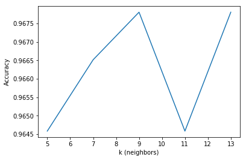

```python
plt.plot(
    knn_params,
    knn_avg_scores)
plt.xlabel("k (neighbors)")
plt.ylabel("Accuracy")
plt.show()
```

8. Get the hyper-parameter, average accuracy, and standard error of the top performing model.

```python
knn_top_index = np.argmax(knn_avg_scores)
knn_top_param = knn_params[knn_top_index]
knn_top_score = knn_avg_scores[knn_top_index]
knn_top_error = knn_models.cv_results_["std_test_score"][knn_top_index]
```

9. Inspect the top performing model.

```python
print("Top knn model is k = {:d} at {:0.2f} +/- {:0.3f} accuracy"
    .format(knn_top_param, knn_top_score, knn_top_error))
```

```
Top knn model is k = 9 at 0.97 +/- 0.015 accuracy
```

### 6. Create Decision Tree Classifier Models.

1. Create a decision tree model.

```python
tree_model = DecisionTreeClassifier()
```

2. Define the hyper-parameters to test (i.e. max_depth = {3, 4, 5, 6, 7}).

```python
tree_params = [3, 4, 5, 6, 7]

tree_param_grid = {"max_depth" : tree_params }
```

3. Create 10 tree models for each of the 5 hyper-parameters using 10-fold cross validation.

```python
tree_models = GridSearchCV(
    estimator = tree_model,
    param_grid = tree_param_grid,
    scoring = "accuracy",
    cv = 10,
    verbose = 1)
```

4. Train all 50 models using the training set.

```python
tree_models.fit(
    X = X_train,
    y = y_train)
```

```
Fitting 10 folds for each of 5 candidates, totalling 50 fits
```

```
[Parallel(n_jobs=1)]: Done  50 out of  50 | elapsed:    2.3s finished
```

```
GridSearchCV(cv=10, error_score='raise',
       estimator=DecisionTreeClassifier(class_weight=None, criterion='gini', max_depth=None,
            max_features=None, max_leaf_nodes=None,
            min_impurity_decrease=0.0, min_impurity_split=None,
            min_samples_leaf=1, min_samples_split=2,
            min_weight_fraction_leaf=0.0, presort=False, random_state=None,
            splitter='best'),
       fit_params=None, iid=True, n_jobs=1,
       param_grid={'max_depth': [3, 4, 5, 6, 7]}, pre_dispatch='2*n_jobs',
       refit=True, return_train_score='warn', scoring='accuracy',
       verbose=1)
```

5. Get the average accuracy for each hyper-parameter.

```python
tree_avg_scores = tree_models.cv_results_["mean_test_score"]
```

6. Display the average accuracy for each hyper-parameter.

```python
for i in range(0, 5):
    print("{:>3} : {:0.3f}"
        .format(tree_params[i], tree_avg_scores[i]))
```

```
  3 : 0.972
  4 : 0.980
  5 : 0.979
  6 : 0.977
  7 : 0.979
```

7. Plot the change in accuracy over each hyper-parameter.

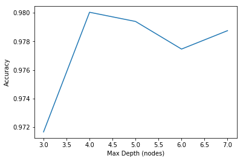

```python
plt.plot(
    tree_params,
    tree_avg_scores)
plt.xlabel("Max Depth (nodes)")
plt.ylabel("Accuracy")
plt.show()
```

8. Get the hyper-parameter, average accuracy, and standard error for the top-performing model.

```python
tree_top_index = np.argmax(tree_avg_scores)
tree_top_param = tree_params[tree_top_index]
tree_top_score = tree_avg_scores[tree_top_index]
tree_top_error = tree_models.cv_results_["std_test_score"][tree_top_index]
```

9. Inspect the top-performing model.

```python
print("Top tree model is k = {:d} at {:0.2f} +/- {:0.3} accuracy"
    .format(tree_top_param, tree_top_score, tree_top_error))
```

```
Top tree model is k = 4 at 0.98 +/- 0.0197 accuracy
```

### 7. Create Neural Network Classifier Models.

1. Create a neural network model with tanh activation functions and 5000 max iterations.

```python
neural_model = MLPClassifier(
    activation = "tanh",
    solver = "sgd",
    max_iter = 5000)
```

2. Define hyper-parameters to test (i.e. hidden_layer_sizes = {3, 4, 5, 6, 7}).

```python
neural_params = [3, 4, 5, 6, 7]

neural_param_grid = {"hidden_layer_sizes" : neural_params }
```

3. Create 10 models for each of the 5 hyper-parameters using 10-fold cross validation.

```python
neural_models = GridSearchCV(
    estimator = neural_model,
    param_grid = neural_param_grid,
    scoring = "accuracy",
    cv = 10,
    verbose = 1)
```

4. Train all 50 models using the training set.  
*Note: This could take a few minutes.*

```python
neural_models.fit(
    X = X_train,
    y = y_train)
```

```
Fitting 10 folds for each of 5 candidates, totalling 50 fits
```

```
[Parallel(n_jobs=1)]: Done  50 out of  50 | elapsed:  1.2min finished
```

```
GridSearchCV(cv=10, error_score='raise',
       estimator=MLPClassifier(activation='tanh', alpha=0.0001, batch_size='auto', beta_1=0.9,
       beta_2=0.999, early_stopping=False, epsilon=1e-08,
       hidden_layer_sizes=(100,), learning_rate='constant',
       learning_rate_init=0.001, max_iter=5000, momentum=0.9,
       nesterovs_momentum=True, power_t=0.5, random_state=None,
       shuffle=True, solver='sgd', tol=0.0001, validation_fraction=0.1,
       verbose=False, warm_start=False),
       fit_params=None, iid=True, n_jobs=1,
       param_grid={'hidden_layer_sizes': [3, 4, 5, 6, 7]},
       pre_dispatch='2*n_jobs', refit=True, return_train_score='warn',
       scoring='accuracy', verbose=1)
```

5. Get the average accuracy for each hyper-parameter.

```python
neural_avg_scores = neural_models.cv_results_["mean_test_score"]
```

6. Display the average accuracy for each hyper-parameter.

```python
for i in range(0, 5):
    print("{:>3} : {:0.3f}"
        .format(neural_params[i], neural_avg_scores[i]))
```

```
  3 : 0.797
  4 : 0.771
  5 : 0.818
  6 : 0.840
  7 : 0.787
```

7. Plot the change in accuracy over each hyper-parameter.

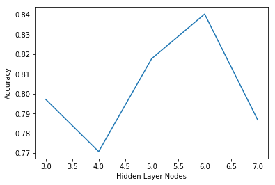

```python
plt.plot(
    neural_params,
    neural_avg_scores)
plt.xlabel("Hidden Layer Nodes")
plt.ylabel("Accuracy")
plt.show()
```

8. Get the hyper-parameter, average accuracy, and standard error for the top-performing model.

```python
neural_top_index = np.argmax(neural_avg_scores)
neural_top_param = neural_params[neural_top_index]
neural_top_score = neural_avg_scores[neural_top_index]
neural_top_error = neural_models.cv_results_["std_test_score"][neural_top_index]
```

9. Inspect the statistics of the top-performing 10 models.

```python
print("Top nnet model is k = {:d} at {:0.2f} +/- {:0.3f} accuracy"
    .format(neural_top_param, neural_top_score, neural_top_error))
```

```
Top nnet model is k = 6 at 0.84 +/- 0.113 accuracy
```

### 8. Evaluate the Models

1. Compare the top three performers numerically.

```python
print("KNN:  {:0.2f} +/- {:0.3f} accuracy"
    .format(knn_top_score, knn_top_error))
print("Tree: {:0.2f} +/- {:0.3f} accuracy"
    .format(tree_top_score, tree_top_error))
print("NNet: {:0.2f} +/- {:0.3f} accuracy"
    .format(neural_top_score, neural_top_error))
```

```
KNN:  0.97 +/- 0.015 accuracy
Tree: 0.98 +/- 0.020 accuracy
NNet: 0.84 +/- 0.113 accuracy
```

2. Compare the top-three performing models visually.

```
(0, 1)
```

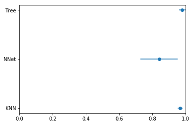

```python
plt.errorbar(
    x = [knn_top_score, tree_top_score, neural_top_score],
    y = ["KNN", "Tree", "NNet"],
    xerr = [knn_top_error, tree_top_error, neural_top_error],
    linestyle = "none",
    marker = "o")
plt.xlim(0, 1)
```

3. Question: Which model would you choose based on this information?

### 9. Test the Final Model

```python
final_model = DecisionTreeClassifier(
    max_depth = 3)
```

2. Train the final model using the entire training set.

```python
final_model.fit(
    X = X_train,
    y = y_train)
```

```
DecisionTreeClassifier(class_weight=None, criterion='gini', max_depth=3,
            max_features=None, max_leaf_nodes=None,
            min_impurity_decrease=0.0, min_impurity_split=None,
            min_samples_leaf=1, min_samples_split=2,
            min_weight_fraction_leaf=0.0, presort=False, random_state=None,
            splitter='best')
```

6. Predict the labels of the test set using the hold-out test set.

```python
final_predictions = final_model.predict(X_test)
```

7. Get the final prediction accuracy.

```python
final_score = accuracy_score(
    y_true = y_test,
    y_pred = final_predictions)
```

8. Inspect the final prediction accuracy.

```python
print(final_score)
```

```
0.9794344473007712
```

### 10. Deploy the Model

Question to be answered: Is Jack (from the Titanic) a high risk or low risk policy?

1. Create an input feature for Jack.

```python
X_jack = pd.DataFrame(
    columns = ["Gender", "State_Rate", "Height", "Weight", "BMI", "Age"],
    data = [[1, 0.09080315, 183, 75, 22.4, 20]])
```

2. Predict the risk class of Jack.

```python
final_model.predict(X_jack)[0]
```

```
'Low'
```

3. Predict the probablility that Jack belongs to the above risk class.

```python
final_model.predict_proba(X_jack)[0][1]
```

```
1.0
```

4. Question: Would you offer life insurance to Jack?